# BANA4137 Case Studies

Yichen Qin (qinyn@ucmail.uc.edu)

# Instructions

1. All data sets used in the case studies are at: https://github.com/yichenqin/dataviz/
2. For each question in each case study, your answer should include: R code, R output, and interpretation of the R output. Below is an example.

**Q1: what is the number of observations?**  
Answer: I use `dim()` to find out of the number of observations.

```r
d = read.csv("college.csv")
dim(d)[1]
```

```
## [1] 1269
```

So there are 1269 observations.

3. You can use **either Microsoft Word software or Rmarkdown** to prepare your report. To use Microsoft Word, just copy and paste R code and output from RStudio to Word.
4. Please submit your report (in doc/html) to Canvas before the deadline.
5. Note that 20% of the total grade depend on how closely your answers follow the visualization principles and [requirement checklist](https://homepages.uc.edu/~qinyn/BANA4137/hwk/requirement.html).

# Case 1 (See Canvas for due date)

**Questions**

1. (5 points) Create a working directory, and download all three data files from Canvas (`CVG_Flights.csv`, `airlines.csv`, and `airports.csv`) to the directory. Read these files into R as three data frames. Here is the code sample/template. `flights = read.csv("CVG_Flights.csv", header = TRUE, na.strings = "")` Note that `na.strings = ""` turns blank `""` to `NA`.
2. (10 points) How many rows and columns are there in each data frame? What does each row represent (a plane, an airport, a flight, or an airline company)? What does each column represent? Explain the meanings of variables to the best of you understanding.
3. (5 points) Merge all three data frames into one data frame according to the IATA code of airlines and airports. For `airports.csv`, please merge it according to both the origin and destination airports in `CVG_Flights.csv`, which means you need to merge twice. Here is the code sample/template. `merged_data <- left_join(flights_data, airlines_data, by=c("AIRLINE"="IATA_CODE"))`
4. (5 point) For this merged data set, print the first six rows.
5. (5 points) For this merged data set, are there any missing values? In what variables are these missing values? What is the percentages of missing values for each variable (i.e., the number of missing values divided by the total number of observations)?
6. (10 points) What is the proportion of canceled flights (to all flights)? How many different cancellation reasons are there?
7. (10 points) For `DEPARTURE_TIME`, are there missing values? Do we know why these values are missing? Hint: canceled flights?
8. (10 points) In the merged data frame, create a new variable (i.e., new column) as the time difference between the `SCHEDULED_TIME` and the `ELAPSED_TIME`, i.e., `SCHEDULED_TIME` - `ELAPSED_TIME`. Print the first six elements of the new variable.
9. (10 points) Extract the observations (i.e., rows) with `AIRLINE` of Delta and `ORIGIN_AIRPORT` of Cincinnati/Northern Kentucky International Airport, and `DEPARTURE_DELAY` time larger than 30 minutes, and put these observations into a new data frame. Print the first six flight numbers of the new data frame.
10. (10 points) Use `group_by()` and `summarize()` to compute the average departure delay time for different airlines. Which airline has the longest and shortest average department delay?
11. (10 points) Use `group_by()` and `summarize()` to compute the average departure delay time for different `ORIGIN_AIRPORT`. Sort these airports descendingly according to the average departure delay time and print the top six rows, i.e., top six airports and their average delay times. Which `ORIGIN_AIRPORT` has the longest and shortest average department delay?
12. (10 points) For flights departing from CVG airport, count how many flights are offered by each airline. Print the entire list.

# Case 2 (See Canvas for due date)

In this homework, we will learn from the pioneer in data visualization, Hans Rosling, and try to recreate one of his visualization. Watch the [Hans Rosling’s presentation](https://www.youtube.com/watch?v=jbkSRLYSojo) and take a look at his [gapminder website](https://www.gapminder.org/tools/#$chart-type=bubbles&url=v1) which shows the same visualization but with higher resolution images.

**Questions**

1 (100 points). Please replicate the Hans Rosling’s visualization as closely as possible using ggplot. You only need to select one year to replicate. Try your best to replicate the symbol colors, shapes, sizes, axes, ticks, labels, text, grids, background colors, background text, and etc. Of course, it is impossible to replicate everything exactly the same. The visualization below should be your target.

[figure not shown]

A slightly different version of the data in this visualization is available in the R package `gapminder`. You can install the package by using `install.packages("gapminder")` and load the data using `data(gapminder)`. Below is an acceptable example of the replication based on the `gapminder` package.

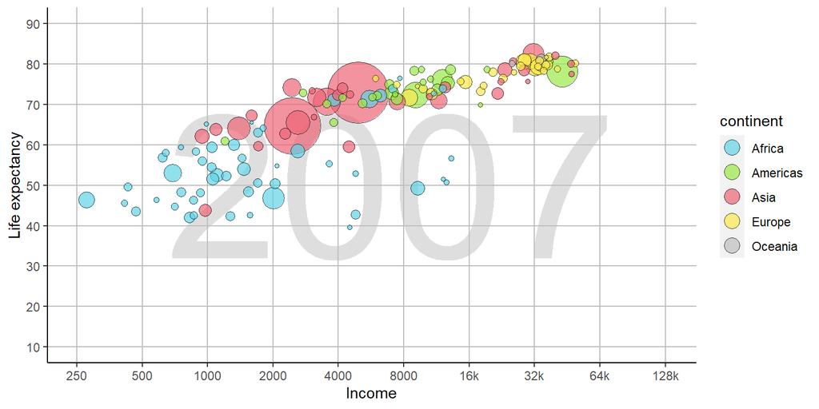

**Useful ggplot Functions**

- To add some background text, you can use: `+ annotate( geom="text", x=... , y=... , label=... , color=... , size=... , alpha=... )`
- To plot the circles for countries, you can consider: `+ geom_point( ... , shape = 21)` Note that if you use `shape=21`, you need to use `fill = ...` to specify the color inside the circle instead of `color = ...`.
- To set transparency, consider: `+ geom_point(...... , alpha = 0.xxx )`
- To set up the colors for each symbol, you can consider: `+ scale_fill_manual( breaks = c("asia", ...... ) , values = c("pink", ......) )`. Alternatively, you can also use : `+ scale_color_manual( same arguments )`
- To set certain ticks in x and y axes, consider: `+ scale_y_continuous( breaks = ... , labels = ... )` and `+ scale_x_continuous( breaks = ... , labels = ... )`.
- To set transformation on x and y axes, consider: `+ scale_y_log10( ... )` and `+ scale_x_log10( ... )`.
- To increase or decrease the sizes of the symbols, consider: `+ scale_size( range = ... )`.
- To remove the background color, consider: `panel.background = element_blank()` inside `+theme()`.
- To set the x and y axes color and style, consider: `axis.line = element_line(color = "black")` inside `+theme()`.
- To set the grid, consider: `panel.grid.major = element_line(color = "grey")` inside `+theme()`.

**Grading Instructions**

The grade depends on:

1. (40 points) Replication of the symbol size (5 points), color (5 points), transparency (5 points), shape (5 points), layout (10 points), correct choice of the variable (10 points).
2. (30 points) Replication of the axes, such as transformation (5 points), tick marks (10 points), text (5 points), labels (10 points), ranges (10 points).
3. (20 points) Replication of the background, such as text (5 points), grid (10 points), color (5 points).
4. (10 points) Anything else that is in the visualization that you feel you can replicate.

# Case 3 (See Canvas for due date)

For this case study, we will analyze a data set on college admission in `college.csv`. In the data set, each row represents one university and each column represents one variable. The continuous variables are admission_rate, sat_avg, undergrads, tuition, faculty_salary_avg, loan_default_rate, median_debt, lon, and lat. The categorical variables are name, city, state, region, highest_degree, control, and gender.

**Questions**

1 (5 points). For `college.csv`, how many variables and how many observations are there in the data? Are there missing values in the data?

2 (10 points). Pick one continuous variables and visualize its distribution. Pick one categorical variables and visualize its distribution. For continuous variables, you can choose from histogram, density plot, violin, and many others. For categorical variables, you can choose from barplot and many others. Describe what you observe in the visualization.

3 (15 points). Pick three pairs of variables (i.e., continuous vs continuous, continuous vs categorical, and categorical vs categorical). For each pair of variables, visualize the association between them. Make sure there are some meaningful patterns in your visualization. Describe what you observe in the visualization.

4 (10 points). Visualize the association between a pair of variables (of your choice) conditional on a third variable (of your choice). Make sure there are some meaningful patterns in your visualization. Describe what you observe in the visualization. This is similar to the previous questions but your visualization involves three variables. You can often use color, shape, size, facet to represent the third variable.

5 (10 points). Visualize the association/interaction among four variables (of your choice). Make sure there are some meaningful patterns in your visualization. Describe what you observe in the visualization. This is similar to the previous questions but your visualization involves four variables. You can often use color, shape, size, facet to represent the third and fourth variables.

6 (50 points). Propose **two** questions you are interested in about this data set, and then answer these questions using visualization. Some example questions can be:

- Are private universities harder to get in? If so, how much harder?
- What is the relationship between SAT and admission rate? Suppose my SAT is XXX, what colleges should I target?
- Where are the most affordable colleges in the US?

Please propose your own questions and do not use the exactly same questions listed above. Note that this question is similar to the questions for final project.